# Regional Statistics

Here, we’re looking at Balanced Bray Curtis Dissimilarity

This code is to look at regional statistics, and figures and stats will end up in supplement.

TO DO: Add bottom temperature, right now it is surface temperature

```r
library(data.table)
library(ggplot2)
library(sf)
library(rgeos)
library(concaveman)
library(raster)
```

[output not shown]

*Additional cleaning (first written in “dissim_metric_space_time.Rmd”)*

Delete observations without CPUE except for MEDITS (we will do trends in abundance metrics for this region)

```r
#delete all rows where wgt_cpue is NA,  unless it is MEDITS region
FishGlob_clean.noNA <- FishGlob_clean[(survey != "MEDITS" & !is.na(wgt_cpue)) | survey == "MEDITS"]

#check
summary(FishGlob_clean.noNA[, wgt_cpue]) #why inf? 13 observations from GSL-N,  I will delete these
```

```
   Min. 1st Qu.  Median    Mean 3rd Qu.    Max.    NA's
    0.0     4.2    26.9     Inf   169.5     Inf  350911
```

```r
FishGlob_clean.noNA <- copy(FishGlob_clean.noNA)[!is.infinite(wgt_cpue), ]
```

Full Name Helper

```r
name_helper <- data.table(Survey_Name_Season = c("Aleutian Islands",
                                    "Baltic Sea Q1",
                                    "Baltic Sea Q4",
                                    "Chile",
                                    "Newfoundland",
                                    "Queen Charlotte Sound",
                                    "Eastern Bering Sea",
                                    "Bay of Biscay",
                                    "English Channel",
                                    "Gulf of Mexico",
                                    "Gulf of Alaska",
                                    "Greenland",
                                    "N Gulf of St. Lawrence",
                                    "S Gulf of St. Lawrence",
                                    "Iceland",
                                    "Irish Sea",
                                    "Mediterranean",
                                    "Namibia",
                                    "NE US Fall",
                                    "NE US Spring",
                                    "N Ireland Q1",
                                    "N Ireland Q4",
                                    "Norway",
                                    "N Sea Q1",
                                    "N Sea Q3",
                                    "Chatham Rise",
                                    "E Coast S Island NZ",
                                    "W Coast S Island NZ",
                                    "Portugal",
                                    "S Georgia Straight",
                                  "Scotian Shelf",
                                  "SE US Fall",
                                  "SE US Spring",
                                  "SE US Summer",
                                  "W Coast US",
                                  "Atlantic Ocean ZA",
                                  "Indian Ocean ZA"),
                          survey_unit = c(
                                  "AI",
                                  "BITS-1",
                                  "BITS-4",
                                  "CHL",
                                  "DFO-NF",
                                  "DFO-QCS",
                                  "EBS",
                                  "EVHOE",
                                  "FR-CGFS",
                                  "GMEX-Summer",
                                  "GOA",
                                  "GRL-DE",
                                  "GSL-N",
                                  "GSL-S",
                                  "ICE-GFS",
                                  "IE-IGFS",
                                  "MEDITS",
                                  "NAM",
                                  "NEUS-Fall",
                                  "NEUS-Spring",
                                  "NIGFS-1",
                                  "NIGFS-4",
                                  "Nor-BTS-3",
                                  "NS-IBTS-1",
                                  "NS-IBTS-3",
                                  "NZ-CHAT",
                                  "NZ-ECSI",
                                  "NZ-WCSI",
                                  "PT-IBTS",
                                  "S-GEORG",
                                  "SCS-SUMMER",
                                  "SEUS-fall",
                                  "SEUS-spring",
                                  "SEUS-summer",
                                  "WCANN",
                                  "ZAF-ATL",
                                  "ZAF-IND"
                          ))
```

```r
all_survey_units <- unique(FishGlob_clean.noNA[, survey_unit])
```

For NZ-CHAT, we want to lump December observations with next year of observations (January, February)

```r
FishGlob_clean.noNA[survey_unit == "NZ-CHAT" & month == 12,  year := year+1, ]
```

Some spp are duplicated within a haul. In all cases, this is due to verbatim names matching to a single accepted name. Therefore, we will sum these wgts and abundances

```r
FishGlob_clean.noNA[, wgt := sum(wgt,  na.rm = T), .(accepted_name,  haul_id)][,
                     wgt_h := sum(wgt_h,  na.rm = T), .(accepted_name,  haul_id)][,
                     wgt_cpue := sum(wgt_cpue,  na.rm = T), .(accepted_name,  haul_id)][,
                     num := sum(num,  na.rm = T), .(accepted_name,  haul_id)][,
                     num_h := sum(num_h,  na.rm = T), .(accepted_name,  haul_id)][,
                     num_cpue := sum(num_cpue,  na.rm = T), .(accepted_name,  haul_id)]
FishGlob_clean.noNA <- unique(FishGlob_clean.noNA[,.(survey, haul_id, country, sub_area, continent, stat_rec, station, stratum, year, month, day, quarter, season, latitude, longitude, haul_dur, area_swept, gear, depth, sbt, sst, num, num_h, num_cpue, wgt, wgt_h, wgt_cpue, verbatim_aphia_id, accepted_name, aphia_id, SpecCode, kingdom, phylum, class, order, family, genus, rank, survey_unit, years_sampled, cell_ID, cell_year_count, year_cell_count, years_sampled_update)])

#make depth numeric
FishGlob_clean.noNA[,depth := as.numeric(depth)]

#make survey and survey unit factors
FishGlob_clean.noNA[,survey:=factor(survey)][,survey_unit:=factor(survey_unit)]

#adjust years
FishGlob_clean.noNA[,year_adj := year-min(year)+1]

#add column for yearly summed biomass (note that MEDITS doesn't have biomass, so it will be excluded from these plots)
FishGlob_clean.noNA[,wgt_cpue_annual := sum(wgt_cpue,na.rm = T),.(year, survey_unit)]

#add column for yearly summed # of hauls
FishGlob_clean.noNA[,haul_id_count_annual := uniqueN(haul_id),.(year, survey_unit)]

#add column for yearly summed # of spp
FishGlob_clean.noNA[,spp_count_annual := uniqueN(accepted_name),.(year_adj, survey_unit)]

FishGlob_richness_year_survey <- unique(FishGlob_clean.noNA[,.(year_adj, survey_unit, spp_count_annual,  year)])

saveRDS(FishGlob_richness_year_survey, file = here::here("output","FishGlob_richness_year_survey.Rds"))
```

Calculate coefficients from lmer for trend in species richness within a region over time

[figure not shown]

```r
#plot year vs richness for each reg
ggplot(data = FishGlob_richness_year_survey) +
  geom_point(aes(x = year, y = spp_count_annual), size = 2) +
  facet_wrap(~survey_unit, scales = "free") +
  theme_classic()
```

```r
richness_trend_lme <- lme(spp_count_annual ~ year_adj, random = (~1 + year_adj|survey_unit),data = FishGlob_richness_year_survey)

richness_trend_coefs <- data.table(coef(richness_trend_lme))
richness_trend_coefs[,survey_unit := rownames(coef(richness_trend_lme))][,Year_Coef_richness := round(year_adj,5)][,Intercept_richness := round(`(Intercept)`,2)]
View(richness_trend_coefs)

richness_trend_coefs <- richness_trend_coefs[name_helper, on = "survey_unit"]

richness_trend_coefs.exp <- richness_trend_coefs[,.(Survey_Name_Season, Intercept_richness, Year_Coef_richness, survey_unit)]

#export this table
fwrite(richness_trend_coefs.exp, file = here::here("output","richness_trend_coefs.exp.csv"))
```

Link trend in beta diversity to trend in gamma diversity

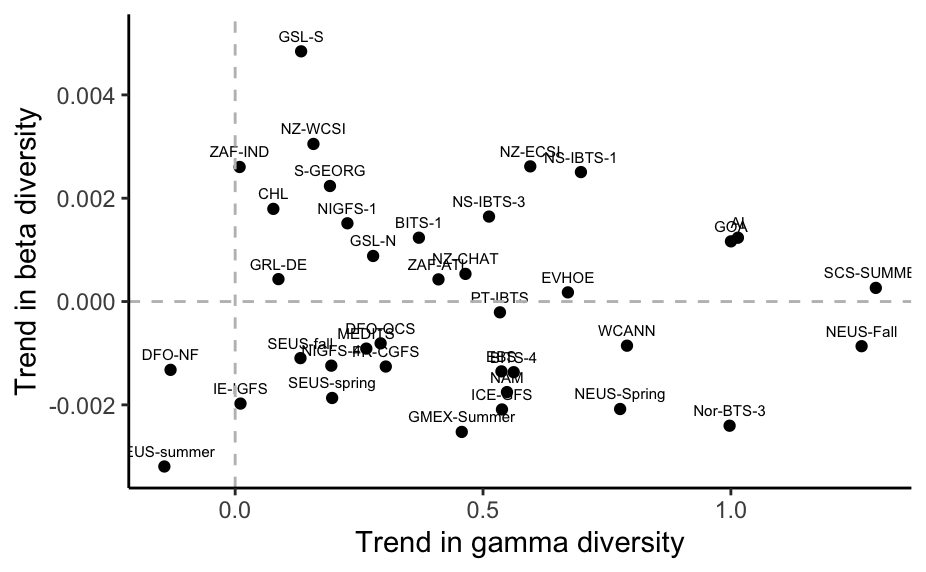

```r
#merge
trend_coefs <- richness_trend_coefs.exp[model_coefs_reduced_length.unique, on = c("survey_unit")]

ggplot(data = trend_coefs, aes(x = Year_Coef_richness, y = year_adj)) +
  geom_point() +
  geom_text(aes(label = survey_unit), size = 2, nudge_y = 0.0003) +
  labs(x = "Trend in gamma diversity", y = "Trend in beta diversity") +
  geom_hline(yintercept = 0, color = "grey", linetype = "dashed") +
  geom_vline(xintercept = 0, color = "grey", linetype = "dashed") +
  theme_classic()

ggsave(path = here::here("figures"), filename = "trends_beta_gamma.jpg")
```

```r
#linear model?
summary(lm(Year_Coef_richness~year_adj, data = trend_coefs))
```

```
Call:
lm(formula = Year_Coef_richness ~ year_adj, data = trend_coefs)

Residuals:
     Min       1Q   Median       3Q      Max
-0.61870 -0.25492 -0.02608  0.18302  0.85436

Coefficients:
             Estimate Std. Error t value Pr(>|t|)
(Intercept)   0.44092    0.06009   7.338 1.41e-08 ***
year_adj    -10.93445   32.54614  -0.336    0.739
---
Signif. codes:  0 ‘***’ 0.001 ‘**’ 0.01 ‘*’ 0.05 ‘.’ 0.1 ‘ ’ 1

Residual standard error: 0.3655 on 35 degrees of freedom
Multiple R-squared:  0.003215,  Adjusted R-squared:  -0.02526
F-statistic: 0.1129 on 1 and 35 DF,  p-value: 0.7389
```

Pull in avg temp values and pull in avg fishing values

```r
 #open fishing and temp data
distances_dissimilarities_allyears.r.temp.fishing <- readRDS( here::here("output","distance_decay","distances_dissimilarities_allyears.r.temp.fishing.rds"))

distances_dissimilarities_allyears.r.temp.fishing[,mean_reg_temp_allyears := mean(sst_mean, na.rm = T),.(survey_unit)][,mean_reg_fishing_allyears := mean(summed_tonnes, na.rm = T),.(survey_unit)]


avg_temp_avg_fishing <- unique(distances_dissimilarities_allyears.r.temp.fishing[,.(survey_unit,mean_reg_fishing_allyears, mean_reg_temp_allyears)])

#link coefficients
year_survey_unit_characteristics <- model_coefs_reduced_length.unique[avg_temp_avg_fishing, on = "survey_unit"]
```

We need to look at gamma vs beta for all regions independently

[figure not shown]

```r
Fishglob_gamma_beta <- FishGlob_richness_year_survey[distances_dissimilarities_allyears.r.temp.fishing, on = c("survey_unit","year")]

ggplot(Fishglob_gamma_beta) +
  geom_point(aes(x = spp_count_annual, y = bray_curtis_dissimilarity_balanced_mean), color = "orange", size = 1) +
  geom_point(aes(x = spp_count_annual, y = jaccard_dissimilarity_turnover_mean), color = "slateblue", size = 1) +
  facet_wrap(~survey_unit, scales = "free") +
  labs(y = "β-diversity", x = "γ-diversity") +
  theme_classic()

ggsave(path = here::here("figures"), filename = "Fishglob_gamma_beta.jpg", width = 11, height = 8, units = "in")
```

For area, we want to delete any areas that overlap with land, therefore, we have to pull in land polygon

```r
#basemap
world <- rnaturalearth::ne_countries(type = "countries", scale="large", returnclass="sf")
```

Calculate stats of all regions

```r
#survey_unit
region_stats <- as.data.table(matrix(nrow = length(all_survey_units)))

region_stats[,survey_unit := as.character(V1)][, survey := as.character(V1)][, spp_num := as.numeric(V1)][,mean_annual_biomass := as.numeric()][,mean_haul_id_count_annual := as.numeric()][, study_period := as.numeric(V1)][, years_sampled := as.numeric(V1)][, lat_range := as.numeric(V1)][, mid_lat := as.numeric(V1)][, lon_range := as.numeric(V1)][, area_km := as.numeric(V1)][, depth_range := as.numeric(V1)][,  mid_depth := as.numeric(V1)][, mean_temp := as.numeric(V1)][, mean_landings := as.numeric(V1)][,bray_coef := as.numeric()][,bray_coef_upr := as.numeric()][,bray_coef_lwr := as.numeric()][,direction_of_change := as.character()][,significant := as.logical()]

  region_stats[,V1:=NULL]

for (i in 1:length(all_survey_units)) {
  reduced_FishGlob_cleaned.10year <- FishGlob_clean.noNA[survey_unit == all_survey_units[i]]

    ####unique lat lon
    lat_lon <- unique(reduced_FishGlob_cleaned.10year[,.(latitude, longitude)])

    pts <- st_as_sf(lat_lon, coords=c('longitude','latitude'), crs=4326 )

    conc <- concaveman(pts, 1,2)

    #delete areas that overlap
    conc_nooverlap <- ms_erase(conc,world[1])

    sf_use_s2(FALSE) #helps with spherical geometry
    area <- st_area(conc_nooverlap) #m2

    #compile into region_Stats table
                  region_stats[i,"survey_unit"] <- paste0(all_survey_units[i])
                  region_stats[i,"survey"] <- word(all_survey_units[i],1, sep = "_")
                  region_stats[i,"spp_num"] <- length(unique(reduced_FishGlob_cleaned.10year[,accepted_name]))
                  region_stats[i,"mean_annual_biomass"] <- mean(reduced_FishGlob_cleaned.10year[,wgt_cpue_annual])
                  region_stats[i,"mean_haul_id_count_annual"] <- mean(reduced_FishGlob_cleaned.10year[,haul_id_count_annual])
                  region_stats[i,"study_period"] <- max(reduced_FishGlob_cleaned.10year$year)-min(reduced_FishGlob_cleaned.10year$year)+1
                  region_stats[i,"years_sampled"] <- length(unique(reduced_FishGlob_cleaned.10year$year))
                  region_stats[i,"lat_range"] <- max(reduced_FishGlob_cleaned.10year$latitude)-min(reduced_FishGlob_cleaned.10year$latitude)
                  region_stats[i,"mid_lat"] <- mean(reduced_FishGlob_cleaned.10year$latitude)
                  region_stats[i,"lon_range"] <- max(reduced_FishGlob_cleaned.10year$longitude)-min(reduced_FishGlob_cleaned.10year$longitude)
                  region_stats[i,"area_km"] <- area/(1000^2)
                  region_stats[i,"depth_range"] <- max(reduced_FishGlob_cleaned.10year$depth, na.rm = T)-min(reduced_FishGlob_cleaned.10year$depth, na.rm = T)
                  region_stats[i,"mid_depth"] <- mean(reduced_FishGlob_cleaned.10year$depth, na.rm = T)
                  region_stats[i,"mean_temp"] <- year_survey_unit_characteristics[survey_unit == all_survey_units[i],mean_reg_temp_allyears]
                  region_stats[i,"mean_landings"] <- year_survey_unit_characteristics[survey_unit == all_survey_units[i],mean_reg_fishing_allyears]
                  region_stats[i,"bray_coef"] <- year_survey_unit_characteristics[survey_unit == all_survey_units[i],year_adj]
                  region_stats[i,"bray_coef_lwr"] <- year_survey_unit_characteristics[survey_unit == all_survey_units[i],lwr]
                  region_stats[i,"bray_coef_upr"] <- year_survey_unit_characteristics[survey_unit == all_survey_units[i],upr]
                  region_stats[i,"Directional_Change"] <- year_survey_unit_characteristics[survey_unit == all_survey_units[i],Directional_Change]
                  region_stats[i,"significant"] <- year_survey_unit_characteristics[survey_unit == all_survey_units[i],significant]
}
```

```
Spherical geometry (s2) switched off
Warning: no non-missing arguments to max; returning -InfWarning: no non-missing arguments to min; returning Inf
```

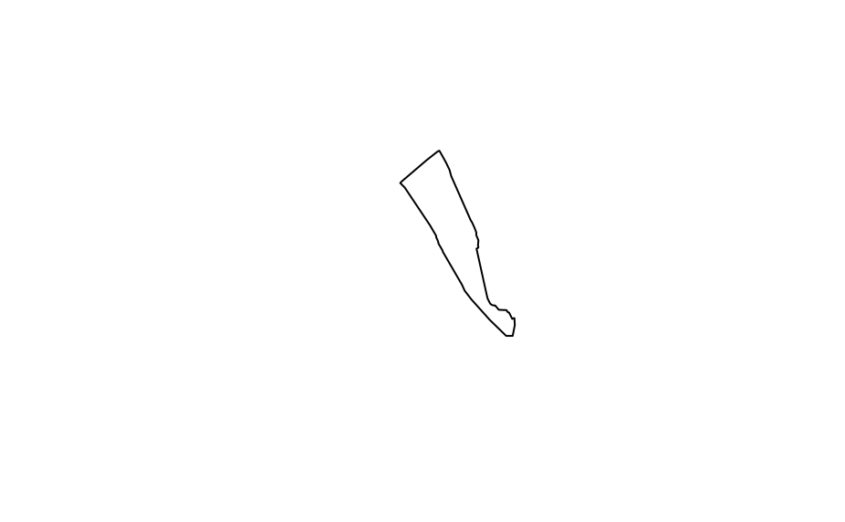

```r
#if any values are -Inf, change to NA
invisible(lapply(names(region_stats),function(.name) set(region_stats, which(is.infinite(region_stats[[.name]])), j = .name,value =NA)))

#add significant directions column
region_stats[,"Significant Trends" := ifelse(significant==T, Directional_Change, "No directional change")]

#add column for avg # of hauls per area
region_stats[,avg_hauls_area := mean_haul_id_count_annual/area_km]


saveRDS(region_stats, here::here("output","region_stats","region_stats.rds"))

#or pull in
region_stats <- readRDS(here::here("output","region_stats","region_stats.rds"))


#test plot
plot(conc)
```

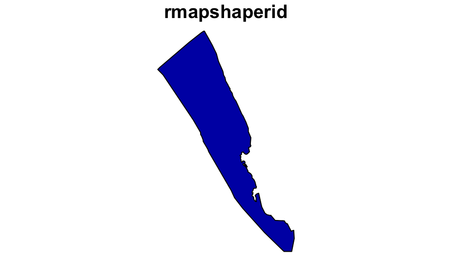

```r
plot(conc_nooverlap)
```

Proportion test (prop homogenizing/differentiating vs. prop not)

H0: The null hypothesis is that the two hemispheres from which the regions were drawn have the same true proportion of homogenizers. A: The alternative is that this proportion is different in at least one of the hemispheres.

H0: The null hypothesis is that the two hemispheres from which the regions were drawn have the same true proportion of differentiators. A: The alternative is that this proportion is different in at least one of the hemispheres.